# Clustering text: comparing TF-IDF, Word2Vec and SBERT embeddings

We are going to cluster the sentences: ["I love cookies", "I love cake", "I hate cookies", "I hate cake", "I like desserts", "My cat's name is Meowzers"]

For that, we need a numeric representation of text, so we create embeddings using TF-IDF, Word2Vec and SBERT:

- TF-IDF does not work since it's not able to understand that cookies, cake and dessert are similar, and that hate and love are very different
- Word2Vec does not work very well because the embeddings of love and hate are not too different, so "i love cookies" and "i hate cookies" are more similar than "i love cookies" and "i like desserts"
- Sentence-BERT (SBERT) works great, because it understands very well that there are sentences liking sweets, sentences hating sweets, and a sentence about a cat

```python
# Sentences to cluster
sentences = ["I love cookies", "I love cake", "I hate cookies", "I hate cake", "I like desserts", "My cat's name is Meowzers"]
```

```python
# Matrix
import numpy as np

# Machine Learning / NLP
from sklearn.decomposition import PCA
from sklearn.feature_extraction.text import TfidfVectorizer
from sentence_transformers import SentenceTransformer
import spacy

# Visualization
from adjustText import adjust_text
import seaborn as sns
import pylab as plt
```

```python
def plot(sentences, embeddings):
    """
    Visualize given embeddings in a 2D space using PCA and annotate them with corresponding sentences.

    Parameters:
    - sentences (list of str): A list of sentences corresponding to each embedding.
      The order should match the embeddings provided.
    - embeddings (array-like): A list or array of embeddings, where each embedding should have the same dimension.

    Notes:
    - This function makes use of the `adjust_text` library to prevent text labels from overlapping.
    - The plot is displayed using `pylab` (referred to as `plt` in the function).

    Returns:
    - A plot with embeddings visualized in a 2D space, annotated with their corresponding sentences.

    """

    # Reduce the embeddings to 2 dimensions using PCA
    X_embedded = PCA(n_components=2).fit_transform(embeddings)

    texts = []
    # Plot each embedding point and its corresponding sentence label
    for text, x, y in zip(sentences, X_embedded[:, 0], X_embedded[:, 1]):
        texts.append(plt.text(x, y, text, fontsize=9))
    plt.plot(X_embedded[:, 0], X_embedded[:, 1], "o")

    # Hide the axis
    plt.axis(False)

    # Set the plot limits
    plt.xlim(X_embedded[:, 0].min()*1.8, X_embedded[:, 0].max()*1.8)
    plt.ylim(X_embedded[:, 1].min()*1.8, X_embedded[:, 1].max()*1.8)

    # Adjust the position of text labels to avoid overlapping
    adjust_text(texts, arrowprops=dict(arrowstyle='->', color='lightgray'))
```

### TF-IDF

TF-IDF does not work since it's not able to understand that cookies, cake and dessert are similar, and that hate and love are very different

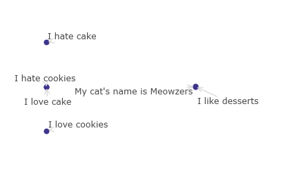

```python
# TFIDF
vectorizer = TfidfVectorizer()

# Create embeddings
X = vectorizer.fit_transform(sentences)

# Plot
plot(sentences, np.asarray(X.todense()))
```

### Word2Vec

Word2Vec does not work very well because the embeddings of love and hate are not too different, so "i love cookies" and "i hate cookies" are more similar than "i love cookies" and "i like desserts"

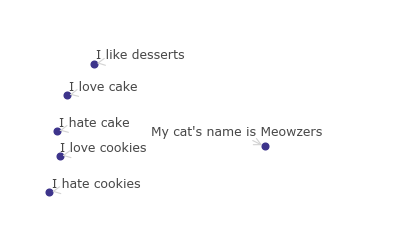

```python
## WORD2Vec
# Load the pre-trained spaCy model
nlp = spacy.load('en_core_web_lg')

# Transform
word2vec_embeddings = np.array([nlp(sentence).vector for sentence in sentences])

# Plot
plot(word2vec_embeddings)
```

### SBERT

- Sentence-BERT (SBERT) works great, because it understands very well that there are sentences liking sweets, sentences hating sweets, and a sentence about a cat

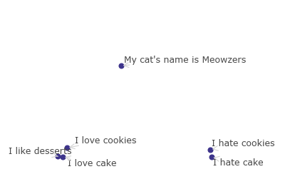

```python
# SBERT
# Load
model = SentenceTransformer('sentence-transformers/paraphrase-multilingual-mpnet-base-v2')

# Transform
embeddings = model.encode(sentences)

# Plot
plot(embeddings)
```